# INTRODUÇÃO AO PYTHON

Autor

João Ricardo F. de Lima

Data de Publicação

7 de agosto de 2025

# Introdução

[^1]Há duas principais maneiras de chegar a esse ambiente de programação:

- **Localmente**: é preciso instalar o Python e uma IDE no seu computador.
- **Na nuvem**: acessa pelo navegador um ambiente já pronto e configurado para rodar Python.

Um ambiente na nuvem pode ser o `Jupyter Notebook/Google Colab` e um ambiente local pode ser o `VsCode` ou `Anaconda`, mas a opção aqui é o Quarto do RStudio.

## Jupyter Notebook/Google Colab

O Jupyter Notebook é uma interface para programar em uma estrutura de “caderno de anotação”: você pode escrever textos, inserir imagens, etc. e adicionar blocos de código, assim como exibir os resultados do código, tudo em um mesmo arquivo. Suas principais vantagens se referem a interface simples e intuitiva para iniciantes, além da facilidade de compartilhar códigos.

Para usar a interface do Jupyter na nuvem, basta seguir estes passos:

1. Ter uma conta no [Google](https://www.google.com.br/);
2. Acessar o [Google Drive](https://drive.google.com/);
3. Clicar em Novo (*New*) > Mais (*More*) > Google Colaboratory.

E com isso já se tem um ambiente de programação em Python.

O que estes procedimentos fazem é criar um arquivo “*Untitled0.ipynb*” no seu Google Drive. Dessa forma, você pode escolher onde criar o arquivo e organizar seus códigos em pastas, se preferir.

O ponto forte está na sua capacidade de fácil integração (Google Drive, Github, entre outros), além de não ser necessário ter instalado a linguagem na máquina.

Para acessar, basta ir no site https://colab.research.google.com/, ter uma conta Google e criar um novo notebook.

A outra possibilidade é ir no site do Python (https://www.python.org/), fazer download do arquivo e depois ir no terminal do Mac/OS ou no Prompt do Windows e instalar o Jupiter (python3 -m pip install jupyter). Depois de instalado, no termina/prompt é digitar `python3 -m notebook` para abrir um Jupyter no navegador e usar em uma interface muito parecida com a do Google Colab.

## Quarto

O uso no Quarto se torna mais tranquilo para quem já usa o RStudio e trabalha tanto com o R quanto o Python. Para inserir os códigos a única diferença é que os `chunks` passam agora a iniciar com `{python}` ao invés de `{r}` depois das três crases.

E ainda existe a possibilidade de rodar Python dentro do R, desde que seja usado o pacote `reticulate`.

Um bom post sobre como preparar o ambiente de trabalho deve ser lido nesta página (https://analisemacro.com.br/data-science/python/introducao-ao-python-como-preparar-o-ambiente-de-trabalho/).

```r
#install.packages("reticulate")
reticulate::py_config()
```

```
python:         /Users/jricardofl/.virtualenvs/r-reticulate/bin/python
libpython:      /Library/Frameworks/Python.framework/Versions/3.12/lib/python3.12/config-3.12-darwin/libpython3.12.dylib
pythonhome:     /Users/jricardofl/.virtualenvs/r-reticulate:/Users/jricardofl/.virtualenvs/r-reticulate
version:        3.12.3 (v3.12.3:f6650f9ad7, Apr  9 2024, 08:18:48) [Clang 13.0.0 (clang-1300.0.29.30)]
numpy:          /Users/jricardofl/.virtualenvs/r-reticulate/lib/python3.12/site-packages/numpy
numpy_version:  1.26.4

NOTE: Python version was forced by VIRTUAL_ENV
```

```python
#py -m pip install jupyter
1 + 1
```

```
2
```

# Instalações de Pacotes

```r
#reticulate::py_install("pandas")
```

```python
#!pip install python-bcb #Google Colab
#py -m pip install python-bcb #Terminal Windows
#python3 -m pip install python-bcb #Terminal Mac
```

## Pacotes pandas e numpy

### **Pandas**

- É uma biblioteca para **análise e tratamento de dados** no Python.
- Oferece uma **sintaxe** e **estrutura de dados** flexível.
- Cobre (quase) tudo que você precisa para **analisar dados**.
- É **gratuito** e de **código aberto**.

Saiba mais: https://pandas.pydata.org/

### **Numpy**

- É uma biblioteca para **computação numérica** no Python;
- Oferece uma **estrutura vetorial e matricial** para dados numéricos;
- É a **base de muitas bibliotecas**;
- É **gratuito** e de **código aberto**.

Saiba mais: https://numpy.org/

### Estrutura de dados tabulares

[figure not shown]

### Leitura e escrita de arquivos *offline*

[figure not shown]

### Manipulação de dados facilitada

[figure not shown]

### Módulo para visualização de dados

[figure not shown]

## Para fazer isso:

O ciclo de análise de dados…

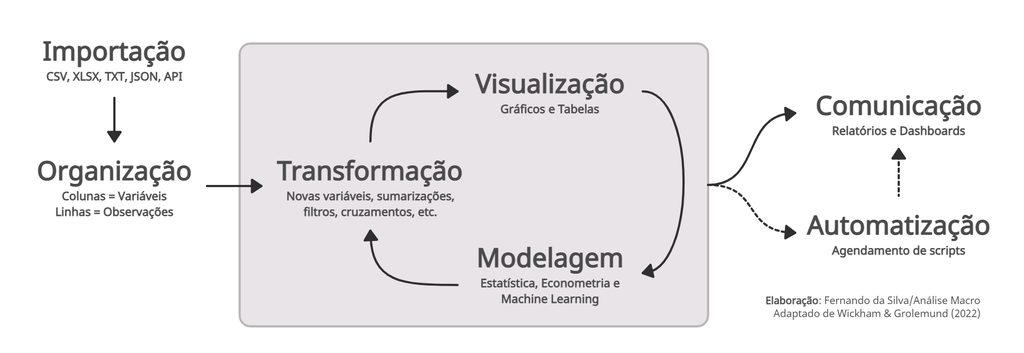

## Com o pandas, numpy e o Python, usa-se isso:

As principais bibliotecas usados para análise de dados.

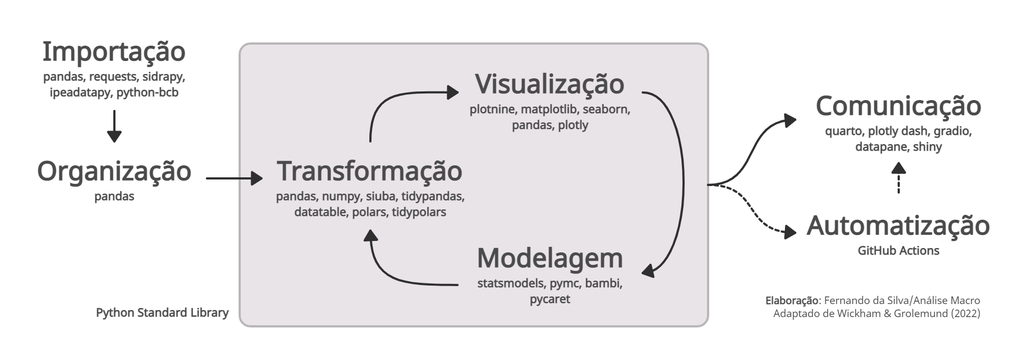

## Panda Series

```python
import pandas as pd

series_obj = pd.Series([4,5,6,3])

series_obj
```

```
0    4
1    5
2    6
3    3
dtype: int64
```

sendo possível criar os valores dos índices

```python
series_obj2 = pd.Series([4,7,8,-2], index = ['a', 'b', 'c', 'd'])
series_obj2
```

```
a    4
b    7
c    8
d   -2
dtype: int64
```

```python
series_obj2.mean()
```

```
4.25
```

```python
series_obj2 * 2
```

```
a     8
b    14
c    16
d    -4
dtype: int64
```

```python
series_obj2['a']
```

```
4
```

## Panda DataFrame

```python
data_raw = {'cursos': ['machine learning', 'econometria', 'séries', 'visualização'],
            'carga horaria': [90, 60, 90, 40],
            'desconto': [True, False, True, False]}

data_raw
```

```
{'cursos': ['machine learning', 'econometria', 'séries', 'visualização'], 'carga horaria': [90, 60, 90, 40], 'desconto': [True, False, True, False]}
```

# Importando Arquivos

Para importar um arquivo CSV *offline* pode-se usar a biblioteca `pandas` no Python:

```python
# Importa o arquivo "dados.csv" salvo na pasta "dados" a partir da pasta atual
import pandas as pd
tabela = pd.read_csv(filepath_or_buffer = "dados/dados.csv")
```

A função `read_csv()` importa o arquivo para um objeto `DataFrame` no Python, basta apontar a localização.

Por padrão, a função tenta adivinhar os tipos das colunas e utiliza a primeira linha como nome das colunas da tabela.

```python
tabela
```

```
           data     pib
0    1996-01-01   99.55
1    1996-04-01  100.44
2    1996-07-01  104.38
3    1996-10-01  103.30
4    1997-01-01  104.32
..          ...     ...
100  2021-01-01  171.54
101  2021-04-01  171.17
102  2021-07-01  171.28
103  2021-10-01  172.41
104  2022-01-01  174.13

[105 rows x 2 columns]
```

```python
tabela.describe()
```

```
              pib
count  105.000000
mean   143.336762
std     26.246198
min     99.550000
25%    116.470000
50%    149.440000
75%    167.760000
max    177.060000
```

```python
tabela.columns
```

```
Index(['data', 'pib'], dtype='object')
```

```python
tabela.index
```

```
RangeIndex(start=0, stop=105, step=1)
```

```python
tabela.head()
```

```
         data     pib
0  1996-01-01   99.55
1  1996-04-01  100.44
2  1996-07-01  104.38
3  1996-10-01  103.30
4  1997-01-01  104.32
```

## Importando CSV com ponto e vírgula (;) de separador

O padrão de arquivos CSV é usar a vírgula como separador dos valores, mas em alguns casos o arquivo CSV pode ter sido gerado com um separador diferente.

No caso de separador ponto e vírgula (;) em um arquivo CSV, o padrão é que os decimais sejam, então, uma vírgula. Para importar nesse formato use os argumentos da função `read_csv()`:

```python
# Importa arquivo CSV com separador ;
tabela = pd.read_csv(filepath_or_buffer = "dados/dados_pv.csv",
        sep = ";", decimal = ",")
tabela.head()
```

```
         data     pib
0  1996-01-01   99.55
1  1996-04-01  100.44
2  1996-07-01  104.38
3  1996-10-01  103.30
4  1997-01-01  104.32
```

## Lidando com codificação de caracteres

O padrão do pacote `pandas` é utilizar a mesma codificação de caracteres de fábrica do Python, que é a UTF-8. Se o arquivo CSV foi gerado com outra codificação pode ser que a importação dos dados saia do resultado desejado. O principal problema que pode acontecer é caracteres especiais, como “ç”, não serem reconhecidos ou a importação gerar um erro. Por exemplo (dados do TSE):

```python
# Importa arquivo CSV com separador ; e encoding padrão (gera um erro)
tse_codificacao_eua = pd.read_csv(
  filepath_or_buffer = "dados/tse.csv",
  sep = ";"
  )
```

```
UnicodeDecodeError: 'utf-8' codec can't decode byte 0xc7 in position 398: invalid continuation byte
```

Para lidar com esses problemas deve-se apontar uma codificação compatível com o arquivo no momento da importação. Basta informar no argumento `encoding` qual é a codificação correta:

```python
# Importa arquivo CSV com separador ; e encoding latin1
tse_codificacao_br = pd.read_csv(
  filepath_or_buffer = "dados/tse.csv",
  sep = ";",
  encoding = "latin_1"
  )
tse_codificacao_br.iloc[range(3), range(6)]
```

```
   DT_GERACAO HH_GERACAO  ...    NM_TIPO_ELEICAO  NR_TURNO
0  01/11/2022   16:05:25  ...  ELEIÇÃO ORDINÁRIA         1
1  01/11/2022   16:05:25  ...  ELEIÇÃO ORDINÁRIA         1
2  01/11/2022   16:05:25  ...  ELEIÇÃO ORDINÁRIA         1

[3 rows x 6 columns]
```

## Importando Excel

Para importar um arquivo Excel *offline* também pode usar a biblioteca **pandas** no Python:

```python
import pandas as pd
tabela_excel = pd.read_excel(io = "dados/dados.xlsx")
tabela_excel
```

```
          data     pib
0   1996-01-01   99.55
1   1996-04-01  100.44
2   1996-07-01  104.38
3   1996-10-01  103.30
4   1997-01-01  104.32
..         ...     ...
100 2021-01-01  171.54
101 2021-04-01  171.17
102 2021-07-01  171.28
103 2021-10-01  172.41
104 2022-01-01  174.13

[105 rows x 2 columns]
```

## Importando determinada Planilha do arquivo Excel

Para importar uma *sheet* específica do arquivo Excel no Python basta apontar o nome ou um *int* com sua posição (índice começa no 0):

```python
tabela_ibcbr1 = pd.read_excel(
  io = "dados/dados.xlsx",
  sheet_name = "ibc_br"
  )
tabela_ibcbr1
```

```
          data  ibc_br
0   2003-01-01   96.15
1   2003-02-01   98.67
2   2003-03-01  103.41
3   2003-04-01  102.19
4   2003-05-01  100.30
..         ...     ...
233 2022-06-01  142.13
234 2022-07-01  149.62
235 2022-08-01  150.09
236 2022-09-01  145.26
237 2022-10-01  143.56

[238 rows x 2 columns]
```

```python
tabela_ibcbr2 = pd.read_excel(
  io = "dados/dados.xlsx",
  sheet_name = 1
)
tabela_ibcbr2
```

```
          data  ibc_br
0   2003-01-01   96.15
1   2003-02-01   98.67
2   2003-03-01  103.41
3   2003-04-01  102.19
4   2003-05-01  100.30
..         ...     ...
233 2022-06-01  142.13
234 2022-07-01  149.62
235 2022-08-01  150.09
236 2022-09-01  145.26
237 2022-10-01  143.56

[238 rows x 2 columns]
```

## Introdução ao NumPy

O NumPy, abreviatura de Numerical Python, é a biblioteca básica mais importante para o uso da análise de dados com Python. Os recursos do uso desse pacote permitem ao usuário realizar operações matemáticas, manipulação de vetores e dados entre outras diversas funcionalidade. Abaixo são mostrados os pontos básicos mais importante do NumPy.

Entre os principais recursos que pode se encontrar com NumPy, estão:

- ndarray: um vetor multidimensional, que oferece operações aritméticas rápidas;
- funções matemáticas para operações com vetores;
- alinhamento e manipulação de dados.

### ndarray

o objeto ndarray é uma classe de objeto no Python que permite a utilização de conjunto de dados como um vetor ou um conjunto de vetores, ou seja, permite realizar operações matemáticas e estatísticas, bem como também é possível manejar os dados de forma mais facilitada.

Um exemplo de calculo que pode-se utilizar é multiplicar um número inteiro com um vetor de dados. Assim como na matemática, o valor escalar repete a operação em todos os valores do vetores (algo que não ocorre sem o NumPy sem definir uma operação de fluxo com for), isto é chamado de vetorização.

```python
import numpy as np

data = np.random.randn(2, 3)

data
```

```
array([[-0.20456292,  2.56247818, -0.81146339],
       [ 0.54958846,  0.47961033,  0.06818309]])
```

```python
data * 5
```

```
array([[-1.02281461, 12.81239092, -4.05731693],
       [ 2.7479423 ,  2.39805163,  0.34091543]])
```

```python
data + data
```

```
array([[-0.40912584,  5.12495637, -1.62292677],
       [ 1.09917692,  0.95922065,  0.13636617]])
```

```python
data.dtype
```

```
dtype('float64')
```

Para controlar o array, um modo simples de criar um vetor ordenado é utilizar arange. Para fatiar os valores, utiliza-se o colchete define o fatiamento conforme a coodernada do valor dentro do array.

```python
arr1 =  np.array([1, 2, 3, 4, 5])

arr1
```

```
array([1, 2, 3, 4, 5])
```

```python
np.arange(10)
```

```
array([0, 1, 2, 3, 4, 5, 6, 7, 8, 9])
```

```python
arr1[1:3]
```

```
array([2, 3])
```

```python
arr3d = np.array([[1, 2, 3], [4, 5, 6], [7, 8, 9], [10, 11, 12]])

arr3d
```

```
array([[ 1,  2,  3],
       [ 4,  5,  6],
       [ 7,  8,  9],
       [10, 11, 12]])
```

Para realizar cálculos estatístico, o próprio NumPy oferece meios de realizar os cálculos.

```python
arr1.mean()
```

```
3.0
```

```python
# Soma
arr1.sum()
```

```
15
```

```python
# Desvio Padrão
arr1.std()
```

```
1.4142135623730951
```

```python
# Mínimo
arr1.min()
```

```
1
```

```python
# Máximo
arr1.max()
```

```
5
```

# Trabalhando com Tabelas no Python

Aqui são exploradas as **operações básicas do pandas** para trabalhar com tabelas:

- Colunas:
  - **Renomear colunas**
  - Selecionar colunas
  - Criar e alterar colunas
- Linhas:
  - Filtrar linhas
- Linhas e Colunas:
  - Sumarizar valores

Estas são operações do dia a dia de uma análise de dados e será visto como utilizar **a biblioteca `pandas`** para facilitar o trabalho.

Grande parte dos procedimentos necessários fazer para **transformar dados brutos em informação útil** podem ser feitos com funções da biblioteca `pandas`, através dos objetos `Series` ou `DataFrame`.

Algumas **funções a serem exploradas** adiante, por componente de uma tabela sobre o qual o verbo se aplica:

- Colunas:
  - **`rename()` muda o nome das colunas**
  - `filter()` seleciona as colunas
  - `assign()` adiciona e altera valores das colunas
- Linhas:
  - `query()` filtra linhas baseado em valores de colunas
- Linhas e Colunas:
  - `groupby()` em conjunto com outras funções (i.e., matemáticas), sumarizam valores de colunas por grupos de linhas

Esse é um resumo, para saber detalhes veja a documentação da biblioteca.

## Exemplo Prático

```python
# Importar bibliotecas
import pandas as pd
import numpy as np
from bcb import sgs

# Dados do IDP/BP - acum. 12m - US$ (milhões) (SGS/BCB)
dados_sgs = sgs.get(codes = {"valor": 24422}, start = "2023-01-01", end = "2024-03-01")

# Exibe dados
dados_sgs.tail()
```

[output not shown]